# Tugas Praktikum 3

M.Syauqyi Habibi

2026-09-10

## Packages

```r
library(dLagM)
library(dynlm)
library(MLmetrics)
library(lmtest)
library(car)
library(rio)
library(readxl)
```

```r
data <- read.csv("NewDelhi_Air_quality.csv")
data <- data[order(data$ts), ]
data$t <- 1:nrow(data)
str(data)
```

```
## 'data.frame':    72 obs. of  13 variables:
##  $ X              : int  0 1 2 3 4 5 6 7 8 9 ...
##  $ AQI            : num  30.2 28.2 26.6 25 26 26 26 24 23 24 ...
##  $ CO             : num  199 198 199 202 205 ...
##  $ datetime       : chr  "2022-10-21:18" "2022-10-21:19" "2022-10-21:20" "2022-10-21:21" ...
##  $ no2            : num  0.0469 0.0465 0.0469 0.0482 0.0489 ...
##  $ o3             : num  55.8 54.9 54.6 55.1 55.8 ...
##  $ pm10           : num  10.5 10.7 11.2 11.1 10.4 ...
##  $ pm25           : num  5.64 4.62 3.52 2.23 1.98 ...
##  $ so2            : num  0.387 0.41 0.402 0.376 0.339 ...
##  $ timestamp_local: chr  "2022-10-21T23:00:00" "2022-10-22T00:00:00" "2022-10-22T01:00:00" "2022-10-22T02:00:00" ...
##  $ timestamp_utc  : chr  "2022-10-21T18:00:00" "2022-10-21T19:00:00" "2022-10-21T20:00:00" "2022-10-21T21:00:00" ...
##  $ ts             : int  1666375200 1666378800 1666382400 1666386000 1666389600 1666393200 1666396800 1666400400 1666404000 1666407600 ...
##  $ t              : int  1 2 3 4 5 6 7 8 9 10 ...
```

```r
head(data)
```

```
##   X  AQI       CO      datetime        no2       o3      pm10     pm25
## 1 0 30.2 198.6027 2022-10-21:18 0.04685717 55.78995 10.486722 5.637410
## 2 1 28.2 197.6013 2022-10-21:19 0.04645554 54.93164 10.719325 4.618169
## 3 2 26.6 198.6027 2022-10-21:20 0.04685717 54.64554 11.155578 3.520902
## 4 3 25.0 201.9405 2022-10-21:21 0.04819594 55.07469 11.116206 2.225919
## 5 4 26.0 205.2784 2022-10-21:22 0.04886533 55.78995 10.405250 1.979471
## 6 5 26.0 208.6163 2022-10-21:23 0.05020411 56.50520  9.402518 1.792677
##         so2     timestamp_local       timestamp_utc         ts t
## 1 0.3874302 2022-10-21T23:00:00 2022-10-21T18:00:00 1666375200 1
## 2 0.4097819 2022-10-22T00:00:00 2022-10-21T19:00:00 1666378800 2
## 3 0.4023313 2022-10-22T01:00:00 2022-10-21T20:00:00 1666382400 3
## 4 0.3762543 2022-10-22T02:00:00 2022-10-21T21:00:00 1666386000 4
## 5 0.3390014 2022-10-22T03:00:00 2022-10-21T22:00:00 1666389600 5
## 6 0.3129244 2022-10-22T04:00:00 2022-10-21T23:00:00 1666393200 6
```

## Pemilihan Peubah Independen

```r
polutan <- data[, c("CO", "no2", "o3", "pm10", "pm25", "so2")]
korelasi <- sapply(polutan, function(x) cor(data$AQI, x))
sort(korelasi, decreasing = TRUE)
```

```
##          o3          CO         no2        pm10        pm25         so2
##  0.97359901  0.79763320  0.73765472  0.08257568 -0.34665524 -0.74247813
```

Peubah polutan Ozon (O3) memiliki tingkat korelasi positif yang paling kuat terhadap AQI di antara seluruh polutan yang tersedia (sekitar $r = 0,974$). Hal ini mengindikasikan bahwa peningkatan konsentrasi Ozon di permukaan berasosiasi sangat kuat dan searah dengan kenaikan Indeks Kualitas Udara (AQI) di Kota New Delhi.

```r
data$Yt <- data$AQI
data$Xt <- data$o3
```

## Pembagian Data Train dan Test

```r
n <- nrow(data)
n_train <- round(0.75 * n)

train <- data[1:n_train, ]
test  <- data[(n_train + 1):n, ]

x_train <- as.vector(train$Xt)
y_train <- as.vector(train$Yt)
x_test  <- as.vector(test$Xt)
y_test  <- as.vector(test$Yt)

train.ts <- ts(train)
test.ts  <- ts(test)

c(n_total = n, n_train = nrow(train), n_test = nrow(test))
```

```
## n_total n_train  n_test
##      72      54      18
```

## Model Koyck

Model Koyck mengasumsikan bahwa pengaruh peubah lag independen terhadap peubah dependen semakin kecil seiring bertambah jauhnya jarak lag, dengan bentuk umum $Y_t = \alpha + \phi Y_{t-1} + \beta X_t + \varepsilon_t$.

```r
model.koyck <- koyckDlm(x = x_train, y = y_train)
summary(model.koyck)
```

```
##
## Call:
## "Y ~ (Intercept) + Y.1 + X.t"
##
## Residuals:
##       Min        1Q    Median        3Q       Max
## -1.135845 -0.266174  0.005908  0.250093  1.063969
##
## Coefficients:
##             Estimate Std. Error t value Pr(>|t|)
## (Intercept)  0.61475    0.92829   0.662    0.511
## Y.1          0.40694    0.07979   5.100 5.25e-06 ***
## X.t          0.26339    0.03991   6.600 2.54e-08 ***
## ---
## Signif. codes:  0 '***' 0.001 '**' 0.01 '*' 0.05 '.' 0.1 ' ' 1
##
## Residual standard error: 0.5015 on 50 degrees of freedom
## Multiple R-Squared: 0.9489,  Adjusted R-squared: 0.9468
## Wald test: 423.5 on 2 and 50 DF,  p-value: < 2.2e-16
##
## Diagnostic tests:
## NULL
##
##                             alpha      beta       phi
## Geometric coefficients:  1.036564 0.2633856 0.4069377
```

```r
aic_koyck <- AIC(model.koyck)
```

[output not shown]

```r
aic_koyck
```

```
## [1] 82.16805
```

```r
bic_koyck <- BIC(model.koyck)
```

[output not shown]

```r
bic_koyck
```

```
## [1] 90.04921
```

pada model dengan O3 sebagai X baik peubah lag $Y_{t-1}$ (koefisien $\phi = 0,407$) maupun $O3_t$ (koefisien $\beta = 0,263$) sama-sama signifikan secara statistik (p-value < 0,001). Model ini mampu menjelaskan sekitar 94,9% keragaman AQI ($R^2 = 0,9489$).

### Peramalan dan Akurasi Model Koyck

```r
fore.koyck <- forecast(model = model.koyck, x = x_test, h = nrow(test))
fore.koyck
```

```
## $forecasts
##  [1] 27.04989 26.69341 25.79480 24.48718 23.20150 22.01896 21.16096 20.24664
##  [9] 19.78038 20.06161 20.74121 21.01777 21.13031 21.64708 23.17609 24.92863
## [17] 26.39536 27.36900
##
## $call
## forecast.koyckDlm(model = model.koyck, x = x_test, h = nrow(test))
##
## attr(,"class")
## [1] "forecast.koyckDlm" "dLagM"
```

```r
mape_koyck <- MAPE(fore.koyck$forecasts, y_test) * 100
mape_koyck
```

```
## [1] 3.065559
```

```r
GoF(model.koyck)
```

```
##              n       MAE           MPE       MAPE      sMAPE      MASE
## model.koyck 53 0.3803495 -0.0004837724 0.01415837 0.01413376 0.5957281
##                   MSE      MRAE    GMRAE
## model.koyck 0.2372882 634632166 8967.964
```

Model Koyck menghasilkan MAPE data uji sebesar 3,07%, jauh lebih baik. Hal ini mengonfirmasi bahwa kekuatan hubungan linier O3 dengan AQI membuat model sederhana seperti Koyck pun mampu memberikan peramalan yang cukup presisi.

## Regression with Distributed Lag (DLM)

Model distributed lag memasukkan peubah X pada waktu sekarang beserta beberapa lag-nya sebagai prediktor. Penentuan panjang lag optimum (q) dilakukan menggunakan `finiteDLMauto()` berdasarkan kriteria AIC.

```r
opt.dlm <- finiteDLMauto(formula = Yt ~ Xt, data = data.frame(train),
                         q.min = 1, q.max = 6, model.type = "dlm",
                         error.type = "AIC", trace = FALSE)
opt.dlm
```

```
##   q - k    MASE      AIC      BIC    GMRAE   MBRAE R.Adj.Sq Ljung-Box
## 5     5 0.39523 27.56666 42.70123 10735.73 0.50361  0.98256 0.1587829
```

Berdasarkan hasil pencarian di atas, panjang lag optimum dipilih pada nilai AIC terendah, yaitu $q = 5$. Pemodelan selanjutnya menggunakan panjang lag optimum tersebut.

```r
q_opt <- as.numeric(rownames(opt.dlm[which.min(opt.dlm$AIC), ]))
model.dlm <- dlm(x = x_train, y = y_train, q = q_opt)
summary(model.dlm)
```

```
##
## Call:
## lm(formula = model.formula, data = design)
##
## Residuals:
##      Min       1Q   Median       3Q      Max
## -0.49667 -0.26418  0.01455  0.26433  0.42858
##
## Coefficients:
##             Estimate Std. Error t value Pr(>|t|)
## (Intercept) -0.11798    0.70946  -0.166    0.869
## x.t          0.47322    0.04947   9.565 4.16e-12 ***
## x.1          0.01961    0.10711   0.183    0.856
## x.2         -0.01879    0.12528  -0.150    0.882
## x.3         -0.08892    0.12534  -0.709    0.482
## x.4          0.15341    0.10726   1.430    0.160
## x.5         -0.07549    0.04941  -1.528    0.134
## ---
## Signif. codes:  0 '***' 0.001 '**' 0.01 '*' 0.05 '.' 0.1 ' ' 1
##
## Residual standard error: 0.2941 on 42 degrees of freedom
## Multiple R-squared:  0.9847, Adjusted R-squared:  0.9826
## F-statistic: 451.6 on 6 and 42 DF,  p-value: < 2.2e-16
##
## AIC and BIC values for the model:
##        AIC      BIC
## 1 27.56666 42.70123
```

```r
aic_dlm <- AIC(model.dlm)
```

[output not shown]

```r
aic_dlm
```

```
## [1] 27.56666
```

```r
bic_dlm <- BIC(model.dlm)
```

[output not shown]

```r
bic_dlm
```

```
## [1] 42.70123
```

### Peramalan dan Akurasi Model DLM

```r
fore.dlm <- forecast(model = model.dlm, x = x_test, h = nrow(test))
fore.dlm
```

```
## $forecasts
##  [1] 27.00970 26.38789 25.02898 23.26125 21.96244 20.87780 20.19260 19.11790
##  [9] 18.98713 19.82576 21.04330 20.86239 20.77019 21.72690 24.32548 26.25894
## [17] 27.44393 27.92547
##
## $call
## forecast.dlm(model = model.dlm, x = x_test, h = nrow(test))
##
## attr(,"class")
## [1] "forecast.dlm" "dLagM"
```

```r
mape_dlm <- MAPE(fore.dlm$forecasts, y_test) * 100
mape_dlm
```

```
## [1] 0.7507941
```

```r
GoF(model.dlm)
```

```
##            n       MAE           MPE        MAPE       sMAPE      MASE
## model.dlm 49 0.2387823 -8.998546e-05 0.008763971 0.008758996 0.3952259
##                  MSE       MRAE    GMRAE
## model.dlm 0.07413832 1119514007 10735.73
```

Berdasarkan nilai AIC terendah dari pencarian `finiteDLMauto()`, diperoleh lag optimum $q = 5$. Hasil estimasi menunjukkan bahwa hanya kadar O3 pada jam yang sama ($O3_t$, koefisien 0,473; signifikan pada p-value < 0,001) yang berpengaruh nyata terhadap AQI, sedangkan kelima lag-nya ($O3_{t-1}, \dots, O3_{t-5}$) secara individual tidak signifikan meskipun tetap mempertahankan model dengan AIC terkecil. Model ini mampu menjelaskan 98,5% keragaman AQI ($R^2 = 0,9847$) dan menghasilkan MAPE data uji terkecil di antara ketiga model, yaitu 0,75%.

## Model Autoregressive Distributed Lag (ARDL)

Model ARDL memasukkan baik lag dari peubah dependen (Y) maupun lag dari peubah independen (X) sekaligus. Penentuan orde optimum (p untuk lag X, q untuk lag Y) dilakukan menggunakan `ardlBoundOrders()` berdasarkan kriteria AIC.

```r
model.ardl.opt <- ardlBoundOrders(data = data.frame(train), ic = "AIC", formula = Yt ~ Xt)
p_opt <- model.ardl.opt$p$Xt
p_opt
```

```
## [1] 12
```

```r
q_opt_ardl <- model.ardl.opt$q
q_opt_ardl
```

```
## [1] 15
```

Berdasarkan pencarian tersebut, diperoleh kombinasi orde optimum $p = 12$ dan $q = 15$ yang selanjutnya digunakan untuk membangun model ARDL final.

```r
model.ardl <- ardlDlm(formula = Yt ~ Xt, data = train, p = p_opt, q = q_opt_ardl)
summary(model.ardl)
```

```
##
## Time series regression with "ts" data:
## Start = 16, End = 54
##
## Call:
## dynlm(formula = as.formula(model.text), data = data)
##
## Residuals:
##      Min       1Q   Median       3Q      Max
## -0.21045 -0.09346  0.01295  0.07151  0.29446
##
## Coefficients:
##              Estimate Std. Error t value Pr(>|t|)
## (Intercept)  3.431843   3.228511   1.063   0.3128
## Xt.t         0.277388   0.167349   1.658   0.1284
## Xt.1         0.452066   0.399193   1.132   0.2839
## Xt.2         0.666284   0.371658   1.793   0.1033
## Xt.3         0.211378   0.407368   0.519   0.6151
## Xt.4         0.419159   0.384097   1.091   0.3007
## Xt.5         0.572994   0.375765   1.525   0.1583
## Xt.6         0.109771   0.376218   0.292   0.7764
## Xt.7         0.573801   0.196372   2.922   0.0152 *
## Xt.8         0.037695   0.392683   0.096   0.9254
## Xt.9         0.541081   0.323650   1.672   0.1255
## Xt.10        0.210644   0.347490   0.606   0.5579
## Xt.11        0.249301   0.274759   0.907   0.3856
## Xt.12       -0.170999   0.228936  -0.747   0.4723
## Yt.1        -0.797573   0.457143  -1.745   0.1116
## Yt.2        -1.045415   0.491987  -2.125   0.0595 .
## Yt.3        -0.799434   0.484168  -1.651   0.1297
## Yt.4        -0.842965   0.517904  -1.628   0.1347
## Yt.5        -0.862464   0.531467  -1.623   0.1357
## Yt.6        -0.764434   0.469948  -1.627   0.1349
## Yt.7        -0.787069   0.407814  -1.930   0.0824 .
## Yt.8        -0.728990   0.577875  -1.262   0.2358
## Yt.9        -0.725199   0.495822  -1.463   0.1743
## Yt.10       -0.465540   0.368025  -1.265   0.2346
## Yt.11       -0.431607   0.275786  -1.565   0.1486
## Yt.12        0.063736   0.284732   0.224   0.8274
## Yt.13        0.114874   0.153354   0.749   0.4711
## Yt.14       -0.047270   0.101910  -0.464   0.6527
## Yt.15       -0.008233   0.098471  -0.084   0.9350
## ---
## Signif. codes:  0 '***' 0.001 '**' 0.01 '*' 0.05 '.' 0.1 ' ' 1
##
## Residual standard error: 0.2478 on 10 degrees of freedom
## Multiple R-squared:  0.9965, Adjusted R-squared:  0.9868
## F-statistic: 102.6 on 28 and 10 DF,  p-value: 4.154e-09
```

```r
aic_ardl <- AIC(model.ardl)
```

[output not shown]

```r
aic_ardl
```

```
## [1] 8.786417
```

```r
bic_ardl <- BIC(model.ardl)
```

[output not shown]

```r
bic_ardl
```

```
## [1] 58.69327
```

### Peramalan dan Akurasi Model ARDL

```r
fore.ardl <- forecast(model = model.ardl, x = x_test, h = nrow(test))
fore.ardl
```

```
## $forecasts
##  [1] 27.08181 27.35156 25.15371 23.67685 21.81961 20.76248 20.17072 19.40023
##  [9] 18.71855 19.33130 21.17956 21.84827 20.58511 21.94301 23.71952 26.10963
## [17] 27.55307 28.01278
##
## $call
## forecast.ardlDlm(model = model.ardl, x = x_test, h = nrow(test))
##
## attr(,"class")
## [1] "forecast.ardlDlm" "dLagM"
```

```r
mape_ardl <- MAPE(fore.ardl$forecasts, y_test) * 100
mape_ardl
```

```
## [1] 1.64491
```

```r
GoF(model.ardl)
```

```
##             n       MAE           MPE        MAPE       sMAPE     MASE
## model.ardl 39 0.1026658 -2.243666e-05 0.003745606 0.003746668 0.195065
##                   MSE      MRAE    GMRAE
## model.ardl 0.01574794 433309280 13355.05
```

Model ARDL menggabungkan pengaruh historis AQI sendiri ($Y_{t-q}$) dan akumulasi pengaruh O3 ($X_{t-p}$). Dengan mengakomodasi dinamika dari kedua belah pihak, model ARDL mampu menekan nilai sisaan (residual error) pada data latih sehingga menghasilkan nilai AIC (8,79) yang paling minimum di antara ketiga model, dengan $R^2 = 0,9965$.

## Perbandingan dan Pemilihan Model

```r
perbandingan <- data.frame(
  Model = c("Koyck", paste0("DLM (q=", q_opt, ")"), paste0("ARDL (p=", p_opt, ", q=", q_opt_ardl, ")")),
  AIC = c(aic_koyck, aic_dlm, aic_ardl),
  BIC = c(bic_koyck, bic_dlm, bic_ardl),
  MAPE_Test = c(mape_koyck, mape_dlm, mape_ardl)
)
perbandingan
```

```
##               Model       AIC      BIC MAPE_Test
## 1             Koyck 82.168046 90.04921 3.0655593
## 2         DLM (q=5) 27.566664 42.70123 0.7507941
## 3 ARDL (p=12, q=15)  8.786417 58.69327 1.6449098
```

```r
dev_koyck <- sum(residuals(model.koyck)^2, na.rm = TRUE)
```

[output not shown]

```r
dev_koyck
```

```
## [1] 12.57627
```

```r
dev_dlm   <- sum(residuals(model.dlm)^2, na.rm = TRUE)
```

[output not shown]

```r
dev_dlm
```

```
## [1] 3.632778
```

```r
dev_ardl  <- sum(residuals(model.ardl)^2, na.rm = TRUE)
```

[output not shown]

```r
dev_ardl
```

```
## [1] 0.6141696
```

## Evaluasi (Uji Asumsi) Model

```r
model.dyn <- dynlm(Yt ~ Xt + L(Xt) + L(Yt), data = train.ts)

dwtest(model.dyn)
```

```
##
##  Durbin-Watson test
##
## data:  model.dyn
## DW = 2.7073, p-value = 0.9894
## alternative hypothesis: true autocorrelation is greater than 0
```

```r
bptest(model.dyn)
```

```
##
##  studentized Breusch-Pagan test
##
## data:  model.dyn
## BP = 11.729, df = 3, p-value = 0.008372
```

```r
shapiro.test(residuals(model.dyn))
```

```
##
##  Shapiro-Wilk normality test
##
## data:  residuals(model.dyn)
## W = 0.96198, p-value = 0.08983
```

**Uji Autokorelasi (Durbin-Watson Test):**

Pengujian menghasilkan nilai statistik $DW = 2,7073$ dengan $p\text{-value} = 0,9894$. Karena $p\text{-value} > 0,05$, maka keputusan yang diambil adalah gagal tolak $H_0$. Hal ini menunjukkan bahwa tidak terdapat gejala autokorelasi positif pada sisaan model.

**Uji Heteroskedastisitas (Breusch-Pagan Test):**

Diperoleh nilai statistik $BP = 11,729$ ($df = 3$) dengan $p\text{-value} = 0,008372$. Karena $p\text{-value} < 0,05$, maka tolak $H_0$. Ini berarti asumsi homoskedastisitas tidak terpenuhi, atau dengan kata lain terdapat indikasi heteroskedastisitas pada ragam sisaan model.

**Uji Normalitas (Shapiro-Wilk Test):**

Hasil pengujian menunjukkan nilai statistik $W = 0,96198$ dengan $p\text{-value} = 0,08983$.Karena $p\text{-value} > 0,05$, keputusan yang diambil adalah gagal tolak $H_0$, yang berarti sisaan menyebar normal.

## Visualisasi Grafik Peramalan

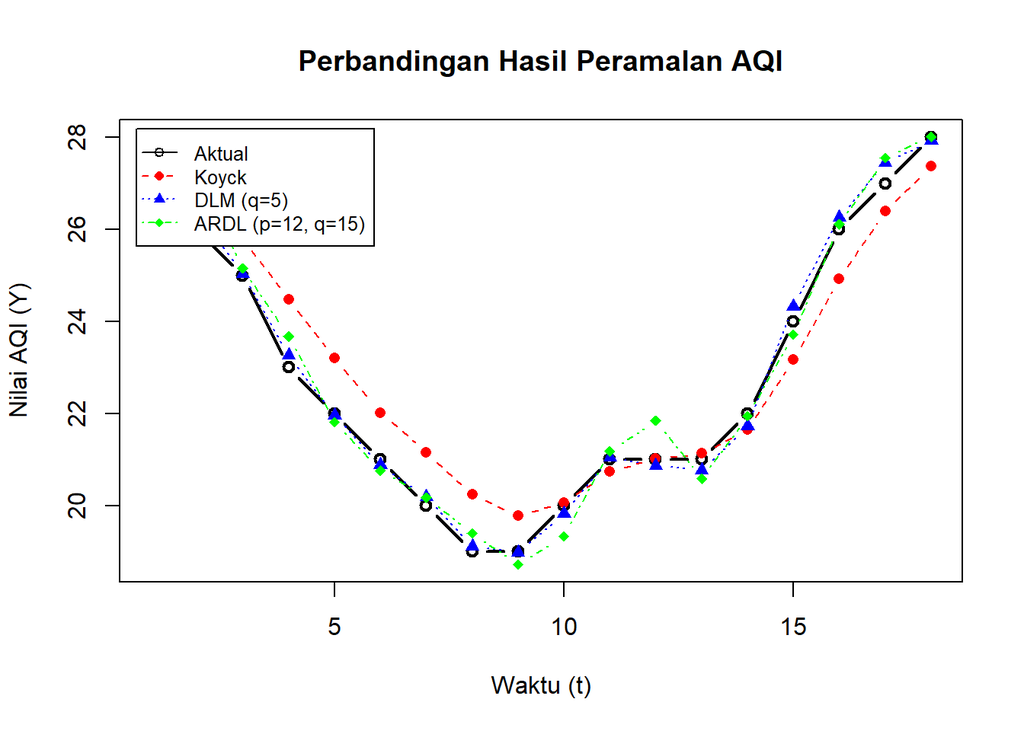

```r
par(mfrow = c(1, 1))

# Plot nilai aktual AQI pada data test
plot(y_test, type = "b", col = "black", lwd = 2, pch = 1,
     ylab = "Nilai AQI (Y)", xlab = "Waktu (t)",
     main = "Perbandingan Hasil Peramalan AQI",
     ylim = range(c(y_test, fore.koyck$forecasts, fore.dlm$forecasts, fore.ardl$forecasts)))

lines(fore.koyck$forecasts, col = "red", type = "b", pch = 16, lty = 2)
lines(fore.dlm$forecasts, col = "blue", type = "b", pch = 17, lty = 3)
lines(fore.ardl$forecasts, col = "green", type = "b", pch = 18, lty = 4)

legend("topleft",
       legend = c("Aktual", "Koyck", paste0("DLM (q=", q_opt, ")"), paste0("ARDL (p=", p_opt, ", q=", q_opt_ardl, ")")),
       col = c("black", "red", "blue", "green"),
       lty = c(1, 2, 3, 4), pch = c(1, 16, 17, 18), cex = 0.8, inset = 0.02)
```

## Tabel Perbandingan Metrik Evaluasi

```r
perbandingan <- data.frame(
  Model = c("Koyck", paste0("DLM (q=", q_opt, ")"), paste0("ARDL (p=", p_opt, ", q=", q_opt_ardl, ")")),
  AIC = c(aic_koyck, aic_dlm, aic_ardl),
  BIC = c(bic_koyck, bic_dlm, bic_ardl),
  Deviance_SSE = c(dev_koyck, dev_dlm, dev_ardl),
  MAPE_Test = c(mape_koyck, mape_dlm, mape_ardl)
)

perbandingan
```

```
##               Model       AIC      BIC Deviance_SSE MAPE_Test
## 1             Koyck 82.168046 90.04921   12.5762729 3.0655593
## 2         DLM (q=5) 27.566664 42.70123    3.6327778 0.7507941
## 3 ARDL (p=12, q=15)  8.786417 58.69327    0.6141696 1.6449098
```

Berdasarkan hasil evaluasi ketiga model regresi dengan peubah lag:

- Model **Koyck** menghasilkan nilai kriteria kebaikan model yang paling tinggi (AIC = 82,17; BIC = 90,05) dan tingkat kesalahan peramalan data uji terbesar di antara ketiganya (MAPE = 3,07%).
- Model **Distributed Lag (DLM $q=5$)** memberikan tingkat kesalahan peramalan pada data uji (*out-of-sample*) yang paling presisi, yaitu MAPE sebesar 0,75%, sekaligus nilai BIC terkecil (42,70) di antara ketiga model. Hal ini menunjukkan bahwa O3 pada jam berjalan merupakan prediktor dominan bagi AQI, dan model ini paling parsimoni (hemat parameter) relatif terhadap performanya.
- Model **ARDL ($p=12, q=15$)** memberikan nilai AIC terkecil (8,79) yang menandakan kecocokan (*goodness-of-fit*) terbaik pada data latih (*in-sample*). Namun, karena jumlah parameternya sangat banyak (28 parameter dari 54 observasi latih), nilai BIC-nya justru menjadi yang terbesar kedua (58,69) akibat penalti kompleksitas model, dan MAPE data ujinya (1,64%) juga sedikit lebih besar dibandingkan DLM.

Jika mengutamakan kriteria kebaikan model pada data latih semata (*goodness-of-fit*), Model ARDL ($p=12, q=15$) unggul dari sisi AIC. Namun, dengan mempertimbangkan keseimbangan antara kesederhanaan model (BIC) dan presisi peramalan ke depan (MAPE data uji), Model **DLM ($q=5$)** dipilih sebagai model terbaik secara keseluruhan karena konsisten unggul pada kedua aspek tersebut tanpa risiko *overfitting* yang tinggi seperti pada model ARDL.

## Kesimpulan

Analisis pada tugas ini menerapkan tiga metode regresi dengan peubah lag (Model Koyck, Distributed Lag Model / DLM, dan Autoregressive Distributed Lag / ARDL) untuk memodelkan hubungan antara Indeks Kualitas Udara / AQI ($Y$) dan konsentrasi Ozon / O3 ($X$) pada data kualitas udara Kota New Delhi. Dari hasil pemodelan dan evaluasi dapat disimpulkan bahwa:

1. Konsentrasi O3 memiliki korelasi paling kuat terhadap AQI ($r = 0,974$) di antara seluruh polutan yang tersedia, sehingga ketiga model regresi peubah lag yang dibangun dengan O3 sebagai X menghasilkan performa yang baik.
2. Model **DLM ($q=5$)** terpilih sebagai model terbaik secara umum karena memiliki nilai BIC terkecil (42,70) dan MAPE data uji terkecil (0,75%), menunjukkan bahwa efek O3 terhadap AQI di Kota New Delhi bersifat cukup instan (kontemporer) dengan sedikit efek lanjutan hingga 5 jam ke depan.
3. Model **ARDL ($p=12, q=15$)** unggul pada kriteria AIC (8,79) untuk data latih, tetapi memiliki risiko kompleksitas berlebih (*overfitting*) mengingat jumlah parameternya yang besar relatif terhadap ukuran data latih.
4. Hasil uji asumsi menunjukkan sisaan model dinamis tidak mengalami autokorelasi (DW, p-value = 0,9894) dan menyebar normal (Shapiro-Wilk, p-value = 0,08983), namun terindikasi adanya heteroskedastisitas (Breusch-Pagan, p-value = 0,008372) yang perlu menjadi catatan untuk pengembangan model lebih lanjut.